# PEC2: Análisis de datos Ómicos

Núria Rivera Brugués

19 de mayo, 2023

# 1 Introducción y Objetivos

Este documento presenta el análisis de microarrays de expresión con R y Bioconductor. Los datos aquí explorados se produjeron para investigar el la inducción de células de cáncer de próstata humana PC-3 con ácido araquidónico.Su objetivo fué el de encontrar genes diferencialmente expresados que corroboraran el conocido papel de los ácidos grasos esenciales en la estimulación de genes relacionados con el crecimineto y la proliferación.

- Los microarrays clasificados como Untreated son las células control sin ningún tratamineto de inducción.
- Los microarrays clasificados como AA_Treated són las células inducidas con ácido araquidónico.

Los microarrays para muestras tratadas y no tratadas se realizaron por cuadruplicado.

El estudio fué publicado por Hughes-Fulford et alt. 2006 (Hughes-Fulford M (2006)) y cargado en la base de datos Gene Expression Omnibus con identificadores: - GDS1736 (Conjunto de datos) y - GSE3737.

# 2 Materiales y métodos

Los datos están disponible en el enlace que se muestra a continuación y se puede descargar directamente desde allí.

https://www.ncbi.nlm.nih.gov/geo/download/?acc=GSE3737&format=file

A continuación se ha descargado el archivo y descomprimido en una subcarpeta de su directorio de trabajo llamada “dades” pendiente de mi directorio de trabajo.

## 2.1 Etapas del analisis

El análisis se ha realizado siguiendo las pautas descritas y resumidos en la figura 1.

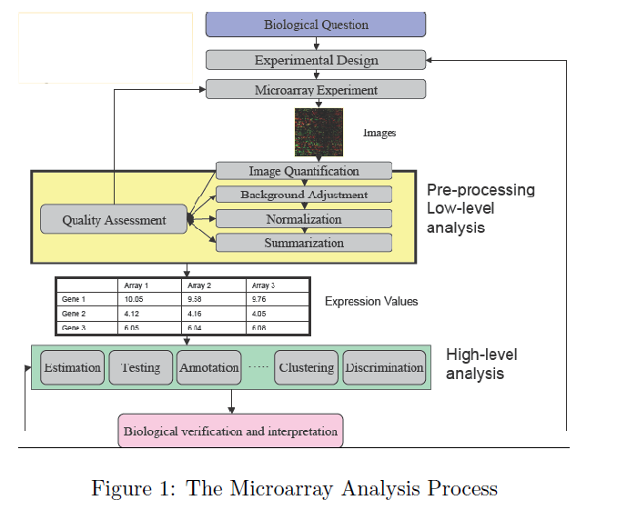

Los valores “crudos” de expresión obtenidos directamente de los archivos CEL se preprocesan utilizando el método de RMA, un proceso de tres pasos que integra la corrección de fondo, la normalización y el resumen de los valores del grupo de sondas en un único valor de expresión “absoluta”. Dichos valores normalizados son la base el análisis aquí realizado.

Los análisis estadísticos se realizaron utilizando el lenguaje estadístico R y las librerías desarrolladas para el análisis de microarray en el proyecto de Bioconductor (www.bioconductor.org).

## 2.2 Métodos de análisis

### 2.2.1 Preparación del sistema: directorios y paquetes

Asignamos la localización del directorio escogido a la variable workingDir. Asumiremos que los datos se encuentran en un subdirectorio del posterior, denominado “dades” que se almacenará en la variable dataDir y que los resultados se almacenaraá en un directorio “results” cuyo nombre completo se almacenará en la variable resultsDir.

El código siguiente se utiliza para instalar los paquetes de Bioconductor necesarios para el análisis.

### 2.2.2 Localización de los datos

Las muestras se agrupan en dos grupos: AA_Treated y Untreated. Esta información se almacena en el archivo “targets.csv”. El archivo targets contiene la identificación de cada archivo CEL con la asignación de cada muestra y cada condición experimental.

El archivo targets para este caso tiene el aspecto que se muestra en la tabla siguiente.

| fileName | grupos | ShortName | Colors |
| --- | --- | --- | --- |
| GSM86079.CEL | Untreated | U1 | green |
| GSM86080.CEL | Untreated | U2 | green |
| GSM86081.CEL | Untreated | U3 | green |
| GSM86082.CEL | Untreated | U4 | green |
| GSM86083.CEL | AA_Treated | T1 | red |
| GSM86084.CEL | AA_Treated | T2 | red |
| GSM86085.CEL | AA_Treated | T3 | red |
| GSM86086.CEL | AA_Treated | T4 | red |

### 2.2.3 Lectura de los datos

El contenido del archivo targets se utiliza en la lectura de los datos y la creación del objeto rawData que contendrá las intensidades “crudas” de cada archivo CEL

```
## ExpressionFeatureSet (storageMode: lockedEnvironment)
## assayData: 506944 features, 8 samples
##   element names: exprs
## protocolData
##   rowNames: 1 2 ... 8 (8 total)
##   varLabels: exprs dates
##   varMetadata: labelDescription channel
## phenoData
##   rowNames: 1 2 ... 8 (8 total)
##   varLabels: fileName grupos ShortName Colors
##   varMetadata: labelDescription channel
## featureData: none
## experimentData: use 'experimentData(object)'
## Annotation: pd.hg.u133a
```

```
## [1] TRUE
```

# 3 Preprocesado

Los datos procedentes de la lectura de los microarrays se denominan datos “crudos” y deben ser pre-procesados de diversas formas antes de analizarlos.

## 3.1 Exploración y Control de Calidad

### 3.1.1 Técnicas univariantes

La exploración de los datos suele basarse en técnicas univariantes como los gráficos de densidad o los diagramas de caja.

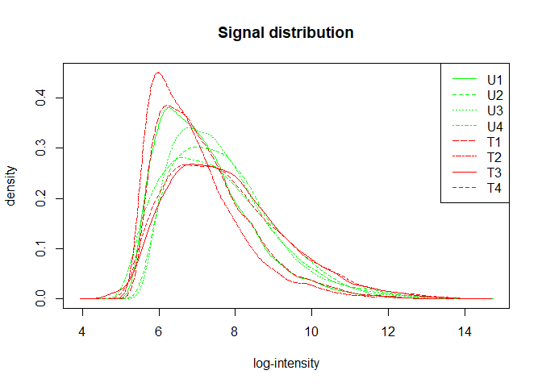

El también llamado histograma permite hacerse una idea de que las distribuciones de los distintos arrays son similares en forma y posición. Aunque los gráficos muestran una cierta heterogeneidad entre muestras el aspecto de todas ellas es compatible con la “normalidad” es decir no sugieren que pueda haber algún problema en los datos.

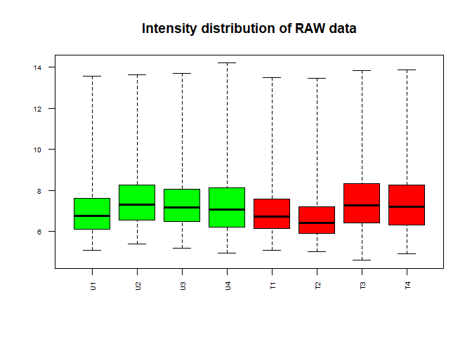

El diagrama de cajas muestra la misma información. Hay heterogeneidad pero no se muestra ninguna diferencia sistemática, lo que sugiere que es conveniente normalizar pero no parece que hayan arrays problemáticos.

### 3.1.2 Técnicas multivariantes

Las técnicas multivariantes como los análisis de conglomerados (“clusters”) de distancias o de análisis de componentes principales

- El gráfico de componentes principales muestra los datos en dimensión reducida de forma que cada componente explica una dimensión de mayor variabilidad e independiente de la siguiente. Representando el porcentaje de variabilidad explicada para cada componente tenemos una medida de la importancia de los grupos que se puedan visualizar. Si la suma de los porecentajes es alta, por ejemplo superior al 50% las conclusiones que de ellos se deriven seran más fiables que con valores bajos.

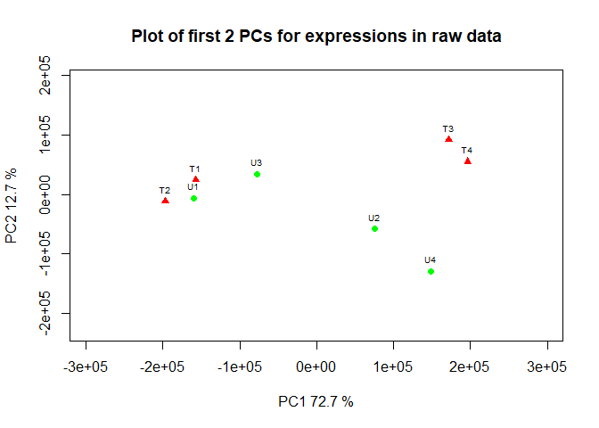

- Un enfoque alternativo al del PCA aunque relacionado es realizar un análisis basado en distancias. Lo hacemos calculando y visualizando la matriz de distancias mediante un mapa de colores o mediante un agrupamiento jerárquico seguido de un dendrograma.

Mapa de colores de las distancias (euclídeas) entre los distintos arrays.

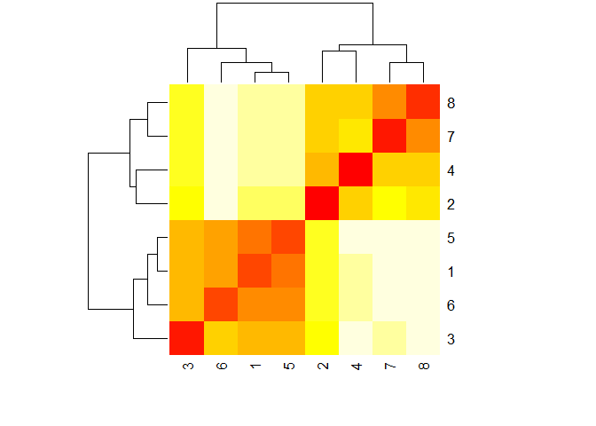

Como en otras representaciones (Heatmaps, PCA) no se observa una agrupación de muestras de tipos similares muy clara.

- Dendrograma resultante de un agrupamiento jerárquico entre las muestras.

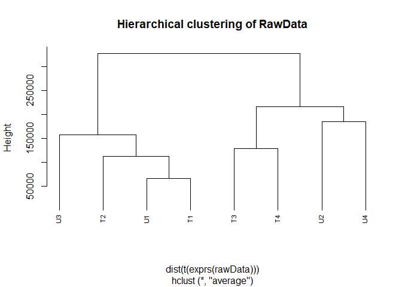

El cluster jerárquico seguido de un dendrograma nos puede ayudar a hacernos una idea de si las muestras se agrupan por condiciones experimentales. se observa una cierta agrupación de muestras de tipos similares aunque también una cierta heterogeneidad, atribuible probablemente a la diferencia entre las unidades experimentales.

Guardo los resultados de la exploración de datos en un QCPlots_Raw.pdf

## 3.2 Control de Calidad con arrayQualitMetrics

El paquete arrayQualitMetrics encapsula todos los análisis anteriores, y alguno más, facilitando su ejecución e incluso su interpretación. La instrucción arrayQualityMetrics lleva a cabo todos los análisi de golpe y genera un informe de resultados con ayudas a la interpretación y a la detección de arrays problemáticos.

## 3.3 Normalización y sumarización

Una vez realizado el control de calidad se procede a normalizar los datos y sumarizarlos.

Utilzamos el método RMA que es el más utilizado entre arrays de affymetrix. Implica 3 etapas: 1- Corrección de fondo 2- Normalización para hacer los valoress de los arrays comparables. 3- Sumarización de las diversas sonsdas asociadas a cada grupo de sondas para dar un único valor.

```
## Background correcting
## Normalizing
## Calculating Expression
```

```
## ExpressionSet (storageMode: lockedEnvironment)
## assayData: 22283 features, 8 samples
##   element names: exprs
## protocolData
##   rowNames: 1 2 ... 8 (8 total)
##   varLabels: exprs dates
##   varMetadata: labelDescription channel
## phenoData
##   rowNames: 1 2 ... 8 (8 total)
##   varLabels: fileName grupos ShortName Colors
##   varMetadata: labelDescription channel
## featureData: none
## experimentData: use 'experimentData(object)'
## Annotation: pd.hg.u133a
```

- El siguiente boxplot de los valores normalizados muestra que los valores han quedado claramente en una escala común facilmente comparables.

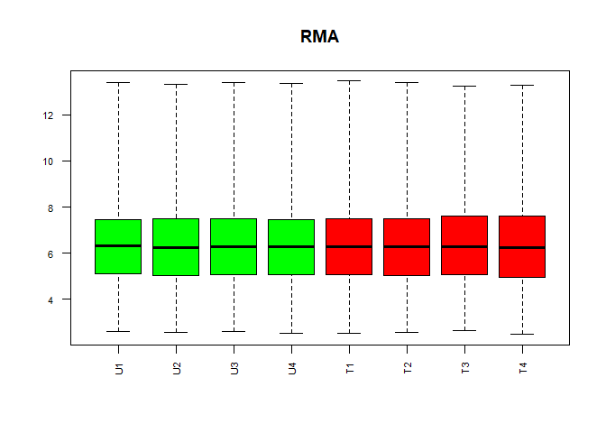

- Un gen que esté diferencialmente expresado es preciso que haya una cierta diferencia entre los grupos, y por lo tanto la varianza global del gen será mayor que la de aquellos que no presentan expresión diferencia. Hacemos un gráfico de la variabilidad de todos los genes;

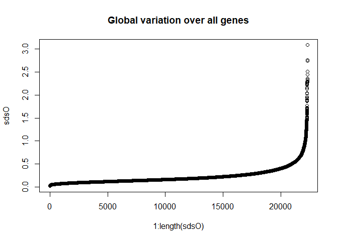

Vemos en la cola derecha como los genes varian mucho más (es decir que presentan expresión diferencial entre las diferentes muestras).

## 3.4 Filtrado

La función nsFilter permite eliminar los genes que, o bien varían poco, o bien no se dispone de anotación para ellos.

Vemos que se ha quitado 7551 duplicados, 9482 de baja variabilidad, quitado 2079 ENTREZID y excluidos 10 características.

Guardamos las Datos Normalizados, los Datos Normalizados Filtrados y el objeto Rda

# 4 Selección de genes diferencialmente expresados (GDE)

## 4.1 Cálculo de estadísticos de test y p-valores (Comparación entre 2 grupos)

Función que calcula el test t de Student y extrae el p-valor resultantede menor a mayor. Así tenemos una lista de candidatos a genes diferencialmente expresados.

```
##             statistic        dm      p.value
## 210229_s_at 21.849111 1.9576216 6.004265e-07
## 211506_s_at 19.052785 3.5052077 1.351637e-06
## 204470_at   17.276017 4.2115957 2.409604e-06
## 209774_x_at 16.435154 5.0729335 3.233019e-06
## 218810_at   13.665766 1.5431018 9.537511e-06
## 207850_at    8.885209 4.5376587 1.131653e-04
## 201502_s_at  8.133259 2.9453334 1.856215e-04
## 204748_at    7.446521 0.9454629 3.022070e-04
## 211668_s_at  7.240270 1.7798711 3.524240e-04
## 202510_s_at  7.065649 0.7424830 4.025516e-04
```

- El volcano plot nos sirve para ver si hay muchos o pocos genes alterados. Representa la significación de cada fenb, medida de “menos el logaritmo del p-valor” frente al campbio de expresión medido por el fold–change o diferencia de medias,que puede considerarse equivalente a una expresión relativa siempre que los datos se encuentren en una escala logarítmica (logaritmo del cociente es la diferencia de logaritmos”).

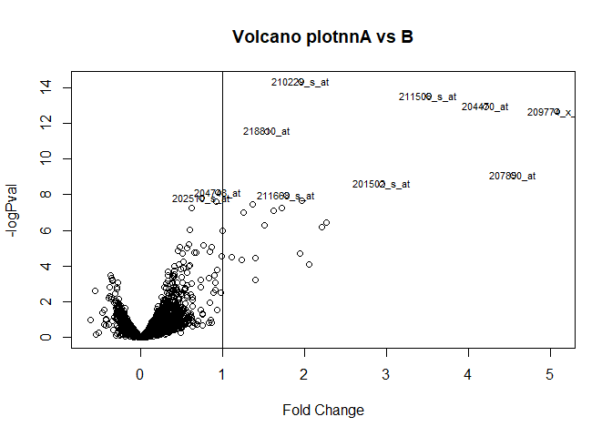

Suponiendo que consideramos válidas las condiciones para aplicar el test-t podemos clasificar los genes por sus p-valores y seleccionar algunos de los genes de la parte superior de la lista (es decir los que tienen menor p-valor de 0.01)

```
## [1] 34
```

## 4.2 Ajuste de p-valores para comparaciones múltiples

Pero tenemos que ajustar los p-valores para no incurrir en falsos positivos

```
##             statistic      p.value  Bonferroni          BH
## 210229_s_at 21.849111 6.004265e-07 0.001897948 0.001897948
## 211506_s_at 19.052785 1.351637e-06 0.004272526 0.002136263
## 204470_at   17.276017 2.409604e-06 0.007616759 0.002538920
## 209774_x_at 16.435154 3.233019e-06 0.010219574 0.002554893
## 218810_at   13.665766 9.537511e-06 0.030148071 0.006029614
## 207850_at    8.885209 1.131653e-04 0.357715523 0.059619254
## 201502_s_at  8.133259 1.856215e-04 0.586749712 0.083821387
## 204748_at    7.446521 3.022070e-04 0.955276236 0.119409530
## 211668_s_at  7.240270 3.524240e-04 1.000000000 0.123779140
## 202510_s_at  7.065649 4.025516e-04 1.000000000 0.127246546
```

El número de genes seleccionado si fijaramos el mismo punto de corte es inferior a si no lo hacemos. Con los p-valores ajustados podemos usar puntos de corte de 0.01 o 0.05 y, si el ajuste controla la tasa de falsos positivos, este valor puede subir hasta 0.25 puesto que lo que indica es que si declaramos diferencialmente expresados los genes con un p-valor ajustado menor o igual que aquel esperaríamos que, de cada 100 que verificaramos se encontraran 25 falsos positivos, lo que puede resultar perfectamente aceptable en estudios exploratorios.

El número de genes seleccionados con un p-valor <0.01 es;

```
## [1] 5
```

El número de genes seleccionados con un p-valor <0.05 es;

```
## [1] 5
```

El número de genes seleccionados con un p-valor <0.25 es;

```
## [1] 17
```

## 4.3 Análisis basado en modelos lineales

Utilizo el paquete limma (linear models for microar- ray data). El método implementado en limma amplía el análisis tradicional utilizando modelos de Bayes empíricos para combinar la información de toda la matriz de datos y de cada gen individual y obtener estimaciones de error mejoradas.

Construimos un modelo lineal, es decir una matriz de diseño y una de contrastes, para el análisis.

### 4.3.1 Matriz de diseño

```
##    Untreated AA_Treated
## U1         1          0
## U2         1          0
## U3         1          0
## U4         1          0
## T1         0          1
## T2         0          1
## T3         0          1
## T4         0          1
## attr(,"assign")
## [1] 1 1
## attr(,"contrasts")
## attr(,"contrasts")$lev
## [1] "contr.treatment"
```

### 4.3.2 Matriz de contraste

```
##             Contrasts
## Levels       AA_Treated-Untreated
##   Untreated                    -1
##   AA_Treated                    1
```

A continuación estimamos el modelo

### 4.3.3 Principales genes expresados diferencialmente

El resultado del análisis se encuentra en el objeto `lmfit` y puede extraerse con la instrucción “topTable”. A fin de controlar el porcentaje de falsos positivos que puedan resultar del alto numero de contrastes realizados simultaneamente los p-valores se ajustan de forma que tengamos control sobre la tasa de falsos positivos utilizando el método de Benjamini y Hochberg.

Muestro la dimension de la tabla y su encabezamiento

```
## [1] 3161    6
```

```
##                logFC   AveExpr         t      P.Value    adj.P.Val         B
## 209774_x_at 5.072934  8.474089 16.164284 7.512023e-10 2.374550e-06 11.485439
## 204470_at   4.211596  8.735476 14.746149 2.283551e-09 3.609153e-06 10.732980
## 211506_s_at 3.505208  8.032616 13.296713 7.892472e-09 8.316034e-06  9.838596
## 207850_at   4.537659  7.163907 10.796426 9.103696e-08 7.194196e-05  7.921152
## 201502_s_at 2.945333 10.208619  8.669243 1.082772e-06 6.845285e-04  5.804597
## 210229_s_at 1.957622  7.717278  8.177837 2.045995e-06 1.077898e-03  5.237358
```

### 4.3.4 Volcano-plot

Como antes el gráfico volcano permite visualizar si hay muchos o pocos genes con un gran fold-change y significativamente expresados o si este número es bajo. Estos gráficos representan en abscisas los cambios de expresión en escala logarítmica y en ordenadas el logaritmo” del p-valor o alternativamente el estadístico B (-odds”).

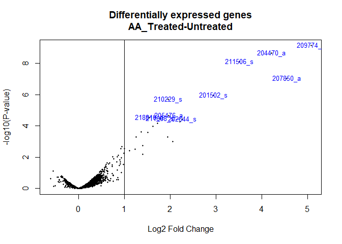

Guardo el gráfico volcano en un documento pdf.

### 4.3.5 Selección genes p-valor ajustado inferior a 0.05

Contabilizo el número de genes diferencialmente expresados teniendo en cuenta p-valor ajustado inferior a 0.05 y lfc=1.

```
##        AA_Treated-Untreated
## Down                      0
## NotSig                 3148
## Up                       13
```

```
## Numero de genes con un p-valor inferior a 0.05 en cada comparacion:
```

```
## Los genes up-regulated en la comparación 'Untreated-AA_Treated' son:  13
```

### 4.3.6 Selección genes p-valor ajustado inferior a 0.01

Contabilizo el número de genes diferencialmente expresados teniendo en cuenta p-valor ajustado inferior a 0.01 y lfc=1.

```
##        AA_Treated-Untreated
## Down                      0
## NotSig                 3155
## Up                        6
```

```
##
## Numero de genes con un p-valor inferior a 0.01 en cada comparacion:
```

```
## Los genes up-regulated en la comparación 'Untreated-AA_Treated'son:  6
```

# 5 Post-procesado de las listas de genes obtenidas

Utilizamos las listas de genes diferencialmente expresados para realizar análisis de interpretación de resultados.

- Anotaciones de genes
- Comparación entre listas (si hacemos comparaciones entre mas de 2 grupos).
- Visualización de todos los genes seleccionados, para ver genes o patrones distintos entre diferentes comparaciones.
- Análisis de significación biológica, mediante análisis de enriquecimiento o mediante “gen set analysis”, para detectar si las listas se encuentran enriquecidas en genes asociados a funciones o procesos biológicos determinados (ver punto 6).

## 5.1 Anotaciones

### 5.1.1 Tablas de anotaciones sencillas

El paquete annafy permite de forma muy simple generar una tabla de anotaciones con hiperenlaces a las bases de datos para cada anotación seleccionada.

Obtenemos un documento html con los genes en este caso con un p-valor inferior a 0.05 y su correspondiente anotación en diferentes bases de datos, su gene ontology, pathways… el fichero se llamma anotations.html

### 5.1.2 Archivos de resultados con tablas hiperenlazables

La función htmlpage permite generar un archivo html a partir de un data.frame con una funcionalidad muy interesante: podemos hacer que una o varias de sus columnas contengan hiperenlaces a alguna base de datos permitiendo acceder a gran cantidad de información sobre los genes de la lista.

### 5.1.3 Lista de genes expresados diferencialmente con sus anotaciones y expresiones.

Vemos los 13 primeros genes

```
##        PROBEID ENTREZID  SYMBOL         ENSEMBL    logFC   AveExpr         t
## 1  209774_x_at     2920   CXCL2 ENSG00000081041 5.072934  8.474089 16.164284
## 2    204470_at     2919   CXCL1 ENSG00000163739 4.211596  8.735476 14.746149
## 3  211506_s_at     3576   CXCL8 ENSG00000169429 3.505208  8.032616 13.296713
## 4    207850_at     2921   CXCL3 ENSG00000163734 4.537659  7.163907 10.796426
## 5  201502_s_at     4792  NFKBIA ENSG00000100906 2.945333 10.208619  8.669243
## 6  210229_s_at     1437    CSF2 ENSG00000164400 1.957622  7.717278  8.177837
## 7    205476_at     6364   CCL20 ENSG00000115009 1.969088  5.757488  6.491078
## 8    218810_at    80149 ZC3H12A ENSG00000163874 1.543102  7.223723  6.324345
## 9  211668_s_at     5328    PLAU ENSG00000122861 1.779871 10.169772  6.213907
## 10 202644_s_at     7128 TNFAIP3 ENSG00000118503 2.268121  8.079448  6.172391
## 11 210538_s_at      330   BIRC3 ENSG00000023445 2.207823  5.364683  5.921133
## 12    39402_at     3553    IL1B ENSG00000125538 1.722010  7.714913  5.810346
## 13 202638_s_at     3383   ICAM1 ENSG00000090339 1.624930  9.043722  5.543650
##         P.Value    adj.P.Val         B
## 1  7.512023e-10 2.374550e-06 11.485439
## 2  2.283551e-09 3.609153e-06 10.732980
## 3  7.892472e-09 8.316034e-06  9.838596
## 4  9.103696e-08 7.194196e-05  7.921152
## 5  1.082772e-06 6.845285e-04  5.804597
## 6  2.045995e-06 1.077898e-03  5.237358
## 7  2.264111e-05 1.022408e-02  3.028163
## 8  2.929572e-05 1.157547e-02  2.786219
## 9  3.482070e-05 1.175054e-02  2.623540
## 10 3.717349e-05 1.175054e-02  2.561885
## 11 5.550118e-05 1.594902e-02  2.182893
## 12 6.641535e-05 1.749491e-02  2.012597
## 13 1.030421e-04 2.505507e-02  1.594687
```

## 5.2 Visualización de los perfiles de expresión con Mapas de color (Heatmap).

Visualización de los 13 genes seleccionados; observamos sus patrones distintos entre los diferentes grupos comparados.

Preparamos los datos y creamos la función color.map()

### 5.2.1 HeatMap 1

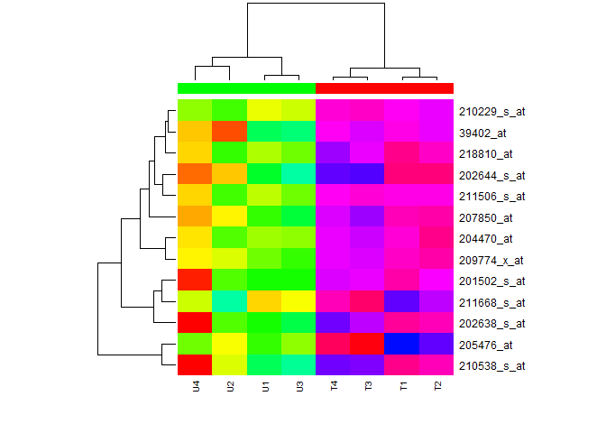

### 5.2.2 HeatMap 2

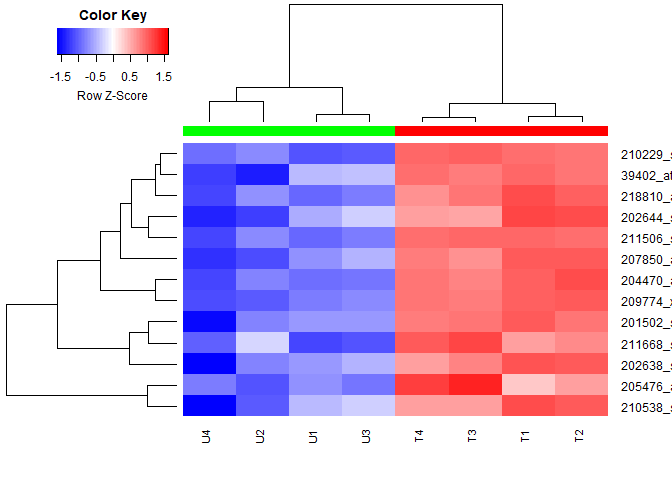

Con los dos heatmaps vemos visualmente como los 13 genes se expresan diferencialmente entre los dos grupos (verde; untreated, rojo; AA_Treated)

# 6 Significación Biológica (Análisis de enriquecimiento)

El análisis de significación biológica busca establecer si, dada una lista de genes seleccionados por estar diferencialmente expresados entre dos condiciones, las funciones y procesos biológicos que los caracterizan aparecen en esta lista con mayor frecuencia que entre el resto de genes analizados.

Hay dos tipos de análisis de enriquecimiento:

- El análisis de sobrerrepresentación “Over-representation Analysis”; toma una lista de genes expresados diferencialmente y busca categorías biológicas en las que una cantidad de genes aparecen con frecuencias “inusualmente” altas. Es decir, busca genes que aparecen con más frecuencia de lo que se esperaría por casualidad en cualquier categoría.
- Los análisis de expresión de conjuntos de genes (“Gene Set Expression Analyses”); funcionan con todos los genes y buscan conjuntos de genes (categorías) expresados diferencialmente. Es decir, busca categorías que, sin contener un número inusualmente alto de genes expresados diferencialmente, estén asociadas con genes que se encuentran en las partes superior o inferior de la lista de genes ordenados por alguna medida de intensidad de diferencia, como el “log-Fold Change”.

## 6.1 Análisis de sobrerrepresentación (“Over-representation Analysis”)

Se pueden usar muchos paquetes para hacer un análisis de enriquecimiento genético. Cada uno de ellos realiza un análisis ligeramente diferente pero las ideas subyacentes son las mismas. Algunos de estos paquetes son:

- GOstats
- topGO
- gperfilador
- generador de perfiles de clúster

### 6.1.1 Anotación GO básica y consulta con GO.db

Seleccionamos los 6 genes top de nuestra lista.

La primera lista muestra la anotación Ontology, y la segunda lista también con la anotación GO

```
##        PROBEID ENTREZID SYMBOL ONTOLOGY
## 1  209774_x_at     2920  CXCL2       BP
## 2  209774_x_at     2920  CXCL2       CC
## 3  209774_x_at     2920  CXCL2       MF
## 4    204470_at     2919  CXCL1       BP
## 5    204470_at     2919  CXCL1       CC
## 6    204470_at     2919  CXCL1       MF
## 7  211506_s_at     3576  CXCL8       BP
## 8  211506_s_at     3576  CXCL8       CC
## 9  211506_s_at     3576  CXCL8       MF
## 10   207850_at     2921  CXCL3       BP
```

```
##        PROBEID ENTREZID SYMBOL         GO EVIDENCE ONTOLOGY
## 1  209774_x_at     2920  CXCL2 GO:0002237      IDA       BP
## 2  209774_x_at     2920  CXCL2 GO:0005515      IPI       MF
## 3  209774_x_at     2920  CXCL2 GO:0005576      TAS       CC
## 4  209774_x_at     2920  CXCL2 GO:0005615      IBA       CC
## 5  209774_x_at     2920  CXCL2 GO:0006935      TAS       BP
## 6  209774_x_at     2920  CXCL2 GO:0006954      IBA       BP
## 7  209774_x_at     2920  CXCL2 GO:0008009      IBA       MF
## 8  209774_x_at     2920  CXCL2 GO:0030593      IBA       BP
## 9  209774_x_at     2920  CXCL2 GO:0045236      IBA       MF
## 10 209774_x_at     2920  CXCL2 GO:0061844      IBA       BP
```

Necesitamos el paquete GO.db para consultar las anotaciones

```
##          GOID ONTOLOGY
## 1  GO:0002237       BP
## 2  GO:0005515       MF
## 3  GO:0005576       CC
## 4  GO:0005615       CC
## 5  GO:0006935       BP
## 6  GO:0006954       BP
## 7  GO:0008009       MF
## 8  GO:0030593       BP
## 9  GO:0045236       MF
## 10 GO:0061844       BP
##                                                                       TERM
## 1                                 response to molecule of bacterial origin
## 2                                                          protein binding
## 3                                                     extracellular region
## 4                                                      extracellular space
## 5                                                               chemotaxis
## 6                                                    inflammatory response
## 7                                                       chemokine activity
## 8                                                    neutrophil chemotaxis
## 9                                          CXCR chemokine receptor binding
## 10 antimicrobial humoral immune response mediated by antimicrobial peptide
```

### 6.1.2 Análisis de sobrerrepresentación usando GOstats

El análisis básico de enriquecimiento se hará con el paquete GOstats de Bioconductor. El análisis se realiza sobre dos bases de datos de anotaciones, la “Gene Ontology” o la “Kyoto Encyclopedia of Genes and Genomes”. Los análisis de este tipo necesitan un número mínimo de genes para resultar fiables por lo que se incluiran en todos los genes con p-valores ajustados inferiores a 0.05 (sin filtrar por minimo “fold-change”).

Creamos dos informed html; con los resultados de “over-representation Analysis” ; GOParams y KEGGparams

- Extraemos la información directamente del análisi usando el summary y visualizamos el inicio de los resultados GOParams

```
## [1] 140   7
```

```
##       GOBPID       Pvalue OddsRatio  ExpCount Count Size
## 1 GO:0071219 5.360345e-14  151.2614 0.2285240     9   53
## 2 GO:0071222 5.360345e-14  151.2614 0.2285240     9   53
## 3 GO:0071345 9.330653e-14  173.6907 0.8882255    12  206
## 4 GO:0071216 1.280257e-13  135.5969 0.2500829     9   58
## 5 GO:0019221 3.675460e-13  104.2652 0.4441128    10  103
## 6 GO:0034097 5.460676e-13  147.3982 1.0262023    12  238
##                                                Term
## 1 cellular response to molecule of bacterial origin
## 2           cellular response to lipopolysaccharide
## 3            cellular response to cytokine stimulus
## 4              cellular response to biotic stimulus
## 5               cytokine-mediated signaling pathway
## 6                              response to cytokine
```

- inicio de los resultados KEGGparams

```
## [1] 12  7
```

```
##   KEGGID       Pvalue OddsRatio  ExpCount Count Size Term
## 1  04621 1.574638e-10 109.28235 0.2123894     7   24 <NA>
## 2  04060 1.376956e-08  50.86667 0.3805310     7   43 <NA>
## 3  05323 4.705473e-08  57.43478 0.2566372     6   29 <NA>
## 4  04062 4.940744e-07  36.33333 0.3716814     6   42 <NA>
## 5  05146 4.751243e-05  30.04545 0.2300885     4   26 <NA>
## 6  05144 1.443366e-04  44.46667 0.1150442     3   13 <NA>
```

### 6.1.3 Análisis de sobrerrepresentación usando clusterProfiler

Visualizamos el encabezamiento del listado

```
##                    ID                                       Description
## GO:0071222 GO:0071222           cellular response to lipopolysaccharide
## GO:0071219 GO:0071219 cellular response to molecule of bacterial origin
## GO:0071216 GO:0071216              cellular response to biotic stimulus
## GO:0019221 GO:0019221               cytokine-mediated signaling pathway
## GO:0032496 GO:0032496                    response to lipopolysaccharide
## GO:0002237 GO:0002237          response to molecule of bacterial origin
## GO:1990868 GO:1990868                             response to chemokine
## GO:1990869 GO:1990869                    cellular response to chemokine
## GO:0030593 GO:0030593                             neutrophil chemotaxis
## GO:0071621 GO:0071621                            granulocyte chemotaxis
##            GeneRatio   BgRatio       pvalue     p.adjust       qvalue
## GO:0071222      9/13 222/18903 2.480144e-15 1.990045e-12 8.564776e-13
## GO:0071219      9/13 234/18903 4.008146e-15 1.990045e-12 8.564776e-13
## GO:0071216      9/13 261/18903 1.082881e-14 3.584338e-12 1.542631e-12
## GO:0019221     10/13 496/18903 3.770755e-14 9.360899e-12 4.028754e-12
## GO:0032496      9/13 339/18903 1.159109e-13 2.301991e-11 9.907336e-12
## GO:0002237      9/13 360/18903 1.995349e-13 3.302303e-11 1.421249e-11
## GO:1990868      6/13  98/18903 2.770575e-11 3.438976e-09 1.480070e-09
## GO:1990869      6/13  98/18903 2.770575e-11 3.438976e-09 1.480070e-09
## GO:0030593      6/13 106/18903 4.478640e-11 4.941433e-09 2.126699e-09
## GO:0071621      6/13 130/18903 1.553680e-10 1.402549e-08 6.036306e-09
##                                                                  geneID Count
## GO:0071222     CXCL2/CXCL1/CXCL8/CXCL3/NFKBIA/CSF2/ZC3H12A/TNFAIP3/IL1B     9
## GO:0071219     CXCL2/CXCL1/CXCL8/CXCL3/NFKBIA/CSF2/ZC3H12A/TNFAIP3/IL1B     9
## GO:0071216     CXCL2/CXCL1/CXCL8/CXCL3/NFKBIA/CSF2/ZC3H12A/TNFAIP3/IL1B     9
## GO:0019221 CXCL2/CXCL1/CXCL8/CXCL3/NFKBIA/CSF2/CCL20/TNFAIP3/BIRC3/IL1B    10
## GO:0032496     CXCL2/CXCL1/CXCL8/CXCL3/NFKBIA/CSF2/ZC3H12A/TNFAIP3/IL1B     9
## GO:0002237     CXCL2/CXCL1/CXCL8/CXCL3/NFKBIA/CSF2/ZC3H12A/TNFAIP3/IL1B     9
## GO:1990868                        CXCL2/CXCL1/CXCL8/CXCL3/CCL20/ZC3H12A     6
## GO:1990869                        CXCL2/CXCL1/CXCL8/CXCL3/CCL20/ZC3H12A     6
## GO:0030593                           CXCL2/CXCL1/CXCL8/CXCL3/CCL20/IL1B     6
## GO:0071621                           CXCL2/CXCL1/CXCL8/CXCL3/CCL20/IL1B     6
```

### 6.1.4 Visualización gráfica de los resultados del Análisis de sobrerrepresentación

- Dotplot

```
## Found more than one class "simpleUnit" in cache; using the first, from namespace 'hexbin'
```

```
## Also defined by 'ggbio'
```

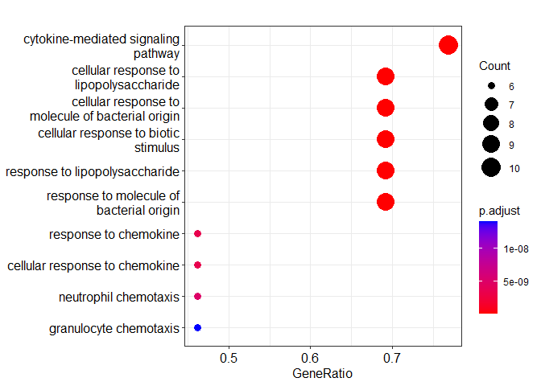

- Visualización de términos GO de modo jerárquico

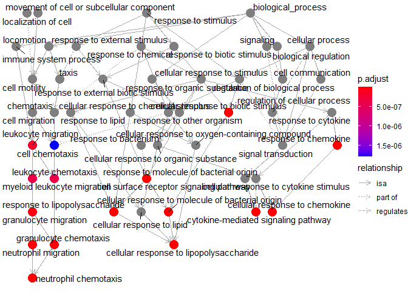

- Red génica de los genes top

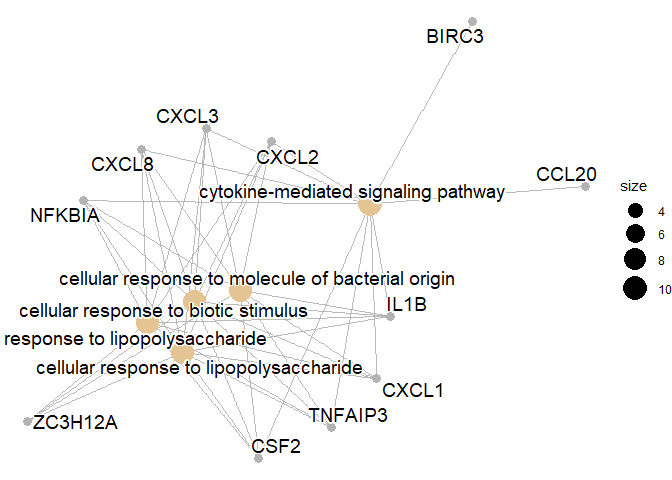

- Mapa de enriquecimiento

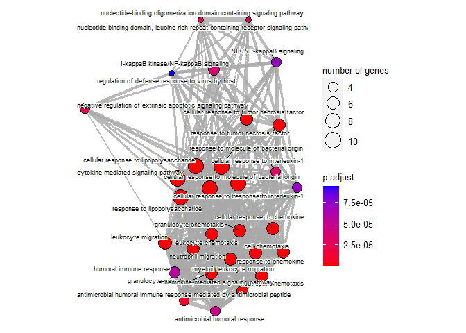

El análisisde sobrerrepresentación adolece de un problema consistente en que parte de una lista de genes que ha sido truncada por un punto de corte más o menos arbitraria, lo que deja a muchos posibles genes interesantes fuera del análisis.

## 6.2 Expresión diferencial de conjuntos de genes (“Gene Set Enrichment Analysis”)

Si en lugar de confiar en las listas de genes, decidimos usar todos los genes en la matriz y confrontarlos con conjuntos seleccionados de genes, podemos usar el enfoque de análisis de enriquecimiento de conjuntos de genes.

Con este método se busca que aunque gen a gen no hubiera expresión diferencial se pueda detectar diferencias a nivel del grupo de genes.

### 6.2.1 GSEA Clásico (con funciones -hoc)

Este método necesita -Una matriz de expresión, con una fila por gen, y una columna por muestra. -Un vector de condiciones experimentales -Un vector de nombres de los genes (se obtendrá del paquete de anotaciones) -Una lista de grupos de genes o ” (se extraerá de un archivo descargado: “PBTs_all_affy.csv”).

- Una vez recopilados los componentes necesarios se ejecuta la llamada al método GSA. Obtenemos la lista -hoc” de genesets

```
## $FDRcut
## [1] 0.5
##
## $negative
##      Gene_set Gene_set_name Score     p-value FDR
## [1,] "6"      "IGT"         "-0.5605" "0"     "0"
## [2,] "17"     "KT1.1"       "-0.2654" "0.01"  "0.065"
## [3,] "16"     "KT2"         "-0.3098" "0.03"  "0.13"
## [4,] "1"      "QCAT"        "-0.215"  "0.09"  "0.234"
## [5,] "18"     "KT2.1"       "-0.3591" "0.09"  "0.234"
## [6,] "2"      "QCMAT"       "-0.1927" "0.23"  "0.4983"
##
## $positive
##      Gene_set Gene_set_name Score p-value FDR
##
## $nsets.neg
## [1] 6
##
## $nsets.pos
## [1] 0
```

- En este ejemplo se utiliza el conjunto de grupos de genes definidos por los pathways de KEGG.

```
## $FDRcut
## [1] 0.5
##
## $negative
##       Gene_set Gene_set_name          Score     p-value FDR
##  [1,] "92"     "KEGG_NEUROACTIVE_LIG" "-0.6657" "0"     "0"
##  [2,] "105"    "KEGG_VASCULAR_SMOOTH" "-0.2113" "0"     "0"
##  [3,] "139"    "KEGG_OLFACTORY_TRANS" "-0.541"  "0"     "0"
##  [4,] "149"    "KEGG_MATURITY_ONSET_" "-0.7324" "0"     "0"
##  [5,] "157"    "KEGG_PRION_DISEASES"  "-0.2244" "0"     "0"
##  [6,] "177"    "KEGG_ASTHMA"          "-0.8245" "0"     "0"
##  [7,] "134"    "KEGG_INTESTINAL_IMMU" "-0.6714" "0.01"  "0.2543"
##  [8,] "23"     "KEGG_TYROSINE_METABO" "-0.2582" "0.02"  "0.2543"
##  [9,] "71"     "KEGG_ABC_TRANSPORTER" "-0.1878" "0.02"  "0.2543"
## [10,] "104"    "KEGG_CARDIAC_MUSCLE_" "-0.1501" "0.02"  "0.2543"
```

[output cut: 32 more lines]

### 6.2.2 GSEA Clásico usando paquete clusterProfiler

Realizamos el análisi de GSEA con clusterProfiler

- Resultado GSEA (clusterProfiler) en una table:

|  | Description | setSize | NES | p.adjust |
| --- | --- | --- | --- | --- |
| hsa04668 | TNF signaling pathway | 51 | 2.595379 | 0.0000000 |
| hsa04657 | IL-17 signaling pathway | 39 | 2.568847 | 0.0000000 |
| hsa05323 | Rheumatoid arthritis | 29 | 2.590041 | 0.0000000 |
| hsa04060 | Cytokine-cytokine receptor interaction | 41 | 2.527301 | 0.0000000 |
| hsa04064 | NF-kappa B signaling pathway | 36 | 2.526412 | 0.0000000 |
| hsa04621 | NOD-like receptor signaling pathway | 56 | 2.357786 | 0.0000000 |
| hsa05167 | Kaposi sarcoma-associated herpesvirus infection | 65 | 2.233797 | 0.0000000 |
| hsa04061 | Viral protein interaction with cytokine and cytokine receptor | 19 | 2.389080 | 0.0000000 |
| hsa04936 | Alcoholic liver disease | 44 | 2.361598 | 0.0000000 |
| hsa05120 | Epithelial cell signaling in Helicobacter pylori infection | 31 | 2.394411 | 0.0000000 |
| hsa05134 | Legionellosis | 29 | 2.438391 | 0.0000000 |
| hsa05146 | Amoebiasis | 28 | 2.405901 | 0.0000000 |
| hsa04062 | Chemokine signaling pathway | 42 | 2.341964 | 0.0000000 |
| hsa05417 | Lipid and atherosclerosis | 71 | 2.182387 | 0.0000000 |
| hsa05202 | Transcriptional misregulation in cancer | 64 | 2.025097 | 0.0000220 |
| hsa05164 | Influenza A | 59 | 1.943182 | 0.0000685 |
| hsa05133 | Pertussis | 23 | 2.181878 | 0.0001140 |
| hsa04620 | Toll-like receptor signaling pathway | 29 | 2.144739 | 0.0001551 |
| hsa05144 | Malaria | 12 | 2.092505 | 0.0001659 |
| hsa04625 | C-type lectin receptor signaling pathway | 33 | 2.056624 | 0.0003221 |
| hsa05140 | Leishmaniasis | 20 | 2.074467 | 0.0004035 |
| hsa05161 | Hepatitis B | 49 | 1.875922 | 0.0015878 |
| hsa05321 | Inflammatory bowel disease | 11 | 1.974509 | 0.0022418 |
| hsa03010 | Ribosome | 37 | -1.912245 | 0.0022474 |
| hsa05142 | Chagas disease | 29 | 2.010685 | 0.0024677 |
| hsa05135 | Yersinia infection | 39 | 1.876096 | 0.0028999 |
| hsa05162 | Measles | 49 | 1.835863 | 0.0030073 |
| hsa04933 | AGE-RAGE signaling pathway in diabetic complications | 37 | 1.909364 | 0.0034844 |
| hsa05143 | African trypanosomiasis | 10 | 1.944097 | 0.0039801 |
| hsa04659 | Th17 cell differentiation | 26 | 1.933245 | 0.0040838 |
| hsa04622 | RIG-I-like receptor signaling pathway | 21 | 1.992445 | 0.0040860 |
| hsa04623 | Cytosolic DNA-sensing pathway | 26 | 1.924169 | 0.0043990 |
| hsa05163 | Human cytomegalovirus infection | 67 | 1.720107 | 0.0043990 |
| hsa05171 | Coronavirus disease - COVID-19 | 74 | 1.693998 | 0.0043990 |
| hsa04640 | Hematopoietic cell lineage | 13 | 1.939292 | 0.0055234 |
| hsa05132 | Salmonella infection | 94 | 1.603095 | 0.0056295 |
| hsa04380 | Osteoclast differentiation | 31 | 1.857411 | 0.0060000 |
| hsa05222 | Small cell lung cancer | 37 | 1.849322 | 0.0060000 |
| hsa04210 | Apoptosis | 52 | 1.760074 | 0.0067526 |
| hsa05145 | Toxoplasmosis | 30 | 1.807008 | 0.0105799 |
| hsa05166 | Human T-cell leukemia virus 1 infection | 75 | 1.643844 | 0.0112548 |
| hsa05322 | Systemic lupus erythematosus | 35 | -1.835647 | 0.0112878 |
| hsa05200 | Pathways in cancer | 144 | 1.460877 | 0.0112878 |
| hsa04932 | Non-alcoholic fatty liver disease | 37 | 1.780043 | 0.0150589 |
| hsa04660 | T cell receptor signaling pathway | 24 | 1.797742 | 0.0171882 |
| hsa04630 | JAK-STAT signaling pathway | 36 | 1.707683 | 0.0254679 |
| hsa05215 | Prostate cancer | 35 | 1.735219 | 0.0312538 |
| hsa05219 | Bladder cancer | 15 | 1.792243 | 0.0318752 |
| hsa05030 | Cocaine addiction | 10 | 1.731928 | 0.0318752 |
| hsa05221 | Acute myeloid leukemia | 18 | 1.726747 | 0.0348844 |

### 6.2.3 Visualización gráfica de “GSEA clusterProfiler”

Visualizamos el resultado GSEA (clusterProfiler) gráficamente y guardamos el resultado en un pdf:

- DOTPLOT

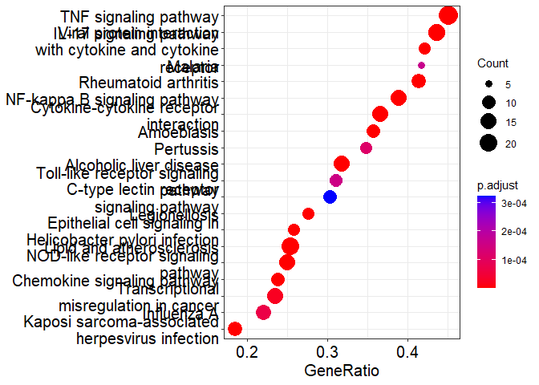

- ENRICHMENT MAP

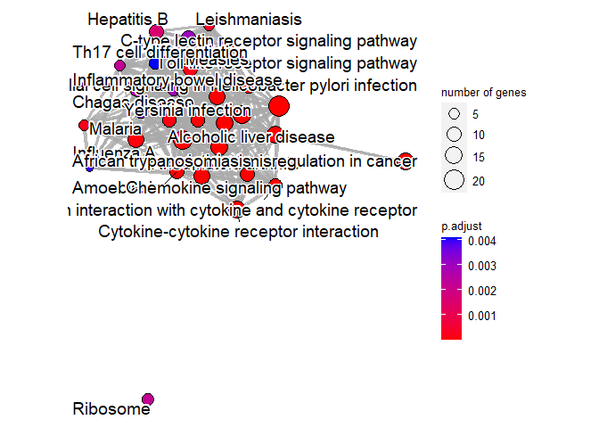

# 7 Resumen de resultados

Los controles de calidad llevados a cabo en la primera parte de este estudio han permitido establecer que los datos con los que se ha trabajado eran de buena calidad, a pesar de presentar una cierta heterogeneidad que queda ilustrada en la incompleta agrupación de las muestras segun su tratamiento.

Los análisis de modelos lineales llevados a cabo sobre los datos normalizados y filtrados han permitido detectar una lista de genes diferencialmente expresados. He seleccionado de esta lista los genes que tienen un p-valor ajustado inferior a 0:05 o 0:01. El número de genes diferencialmente expresado en cada caso es: 13 y 6. En todas las comparaciones se trata de genes up-regulados en la comparación AA_Treated vs Untreated. Con otras palabras, la expresión génica de estos 13 genes es inducida con el tratamiento con ácido araquidónico y por lo tanto los valores de expresión son mas altos que los de las condiciones normales.

He realizado dos tipos de análisis de enriquecimiento para identificar funciones y procesos biológicos en los que los resultados indican mayor participación. Esto nos ayudará establecer la importancia y significación biológica de los hallazgos de este análisis.

- El análisis de sobrerrepresentación usando el paquete GOstats ha permitido detectar una serie de funciones y procesos biológicos que caracterizan las listas de genes seleccionadas en las bases de datos de anotaciones más populares, la Gene Ontology (GO) y la “Kyoto Enyclopedia of Genes and Genomes”. Estas listas pueden verse en las tablas “GOResults.Top.html” y “KEGGResults.Top.html” . También he hecho el análisi de sobrerrepresentación con el paquete clusterProfiler el resultado se ha guardado en el archivo clusterProfiler_ORAresults_UpGO.csv y representado gráficamente.

Vemos que los principales pathways implicados son;

1-cytokine-mediated signaling pathway 2-cellular response to lipopolysaccharide 3-cellular response to molecule of bacterial origin 4-cellular response to biotic stimulus 5-response to lipopolysaccharide 6-response to molecule of bacterial origin 7-response to chemokine 8-cellular response to chemokine 9-neutrophil chemotaxis 10-granulocyte chemotaxis

Mediante la red génica de los genes mas expresados vemos que de esta lista las rutas metabólicas con mayor implicación son ; 1, 2, 3, 4, 5 Con la visualización de terminos jerárquicos vemos que hay implicación en rutas de localización celular y las de respuesta a estímulos. Mediante el mapa de enriquecimiento vemos los pathways implicados como se relacionan entre si. Es decir podemos ver visualmente que procesos globalmente han sido alterados y que consecuencias tiene tratar con ácido araquidónico células cancerígenas.

- Si en lugar de confiar en las listas de genes, decidimos usar todos los genes en la matriz y confrontarlos con conjuntos seleccionados de genes, podemos usar el enfoque de análisis de enriquecimiento de conjuntos de genes (“Gene Set Enrichment Analysis”).

Con el GSEA Clásico utilizando el conjunto de grupos de genes definidos por los pathways de KEGG identificamos 36 rutas down-regulated y 4 rutas up.reguladas. Estas corresponden a: CHEMOKINE_SIGNAL, TOLL_LIKE_RECEP, NOD_LIKE_RECEPT, EPITHELIAL_CELL

Los resultados del GSEA usando clusterProfiler se presentan en una tabla donde se indica el nivel de significación y el número de genes identificados que estan implicado en esa ruta. Los pathways identificados con mayor significación son:

1- TNF signaling pathway 2- IL-17 signaling pathway 3- Rheumatoid arthritis 4- Cytokine-cytokine receptor interaction 5- NF-kappa B signaling pathway 6- NOD-like receptor signaling pathway 7- Kaposi sarcoma-associated herpesvirus infection 8- Viral protein interaction with cytokine and cytokine receptor 9- Alcoholic liver disease 10- Epithelial cell signaling in Helicobacter pylori infection

Los resultados también se visualizan gráficamente con un Dotplot y un mapa de enriquecimiento, los cuales permiten hacerse una idea rápida de estos resultados mencionados.

# 8 Discusión

El artículo publicado por Hughes-Fulford et alt. 2006 (Hughes-Fulford M (2006)) concluye que en conjunto, los datos sugieren que el ácido araquidónico a través de la conversión a PGE2 juega un papel importante papel en la estimulación de genes relacionados con el crecimiento y la proliferación a través de la señalización de PI3K y la translocación de NF-KB al núcleo.

Para llegar a sus conclusiones de manera exacta y poder corroborarlas, deberíamos de poder hacer todos los experimentos que se incluyen en el artículo. No obstante nuestro análisis preliminar muestra como los resultados de los chips apuntan ya hacia esa conclusión. En concreto vemos que; 1- el ácido araquídónico estimula la sobreexpresión de 13 genes (CXCL2, CXCL1, CXCL8, CXCL3, NFKBIA, CSF2, CCL20, ZC3H12A, PLAU, TNFAIP3, BIRC3, IL1B y ICAM1).2- Las rutas de señalización mediante Cytokine, TNF, IL−17, Toll−like receptor, Chemokine y NF−kappa B; la interacción Cytokine−cytokine receptor; y la respuesta celular a liposacaridos son los procesos biológicos principalmente alterados.

Como limitaciones de este estudio podemos destacar que las muestras utilizadas (8 en total y 4 por condición) es bastante limitado lo que determina que el estudio tenga poca potencia por lo que probablemente habrá menos reproducibilidad y más falsos negativos de los que sería deseable si se utilizara un mayor número de muestras.

Por otro lado en cada paso del proceso se han tomado decisiones relativamente arbitrarias acerca de los métodos a seguir para la normalización, filtrado, selección de genes, etc. Sería interesante saber como cambian los resultados si se tomaran otras decisiones.

Finalmente debe de tenerse en cuenta que cualquier gen que se acabe considerando realmente expresado diferencialmente se tendrá que verificar mediante otras técnicas como RT-qPCR por lo que este análisis debe de considerarse como un paso hacia el descubrimiento de genes candidatos, no como una fase definitiva.

# 9 Apéndices

El archivo Rivera_Brugues_Nuria_PEC2.rmd contiene el siguiente código R utilizado para realizar todos los análisis presentados en este informe.

```r
######### Set directorios############################################################
####################################################################################
workingDir <-getwd()
dataDir <- file.path(workingDir, "dades")
resultsDir <- file.path(workingDir, "results")



#####################################################################################
# Set directorios ####################################################################
if (!require(BiocManager)) install.packages("BiocManager")

installifnot <- function (pkg){
  if (!require(pkg, character.only=T)){
    BiocManager::install(pkg)
  }
}

bioCifnot <- function (packageName){
  if (!(require(packageName, character.only=TRUE))) {
    BiocManager::install(packageName)
  }else{
    detach(paste ("package", packageName, sep=":"), character.only=TRUE)
  }
}

# BiocManager::install() # Actualiza paquetes instalados
installifnot("oligo")
installifnot("limma")
installifnot("Biobase")
installifnot("arrayQualityMetrics")
installifnot("genefilter")
installifnot("annotate")
installifnot("xtable")
installifnot("gplots")
installifnot("GOstats")

library("BiocManager")
# BiocManager::install("hgu133plus2.db")
#BiocManager::install("pd.ht.hg.u133.plus.pm")
library("affy")
library("GO.db")
library("oligo")
library(annaffy)
library("dplyr")
library("pd.ht.hg.u133.plus.pm")
library("hgu133plus2.db")
#BiocManager::install("affycoretools")
library("affycoretools")
library("ggplot2")
library("hgu133plus2.db")
#BiocManager::available("^org\\.")
library(org.Hs.eg.db)
installifnot("knitr")
installifnot("xml2")
installifnot("ggnewscale")


bioCifnot ("hgu133a.db")
bioCifnot ("annotate")
bioCifnot ("Rgraphviz")
bioCifnot ("GOstats")
bioCifnot ("clusterProfiler")


#####################################################################################
# Localización de datos ####################################################################

library(Biobase)
#TARGETS
targetsDF <-read.table(file=file.path(dataDir,"targets.csv"), header = TRUE, sep=",")

#DEFINE SOME VARIABLES FOR PLOTS
sampleNames <- as.character(targetsDF$ShortName)
sampleColor <- as.character(targetsDF$Colors)
# Creamos un objeto AnnotatedDataFrame
targets <- AnnotatedDataFrame(targetsDF)
kable(targetsDF)


#####################################################################################
# Lectura de datos ####################################################################
library("pd.hg.u133a")
require(affy)
CELfiles <- targetsDF$fileName
rawData <- read.celfiles(file.path(dataDir,CELfiles), phenoData=targets)
show(rawData)
numSamples <- nrow(pData(rawData))


#####################################################################################
# Exploración de datos ####################################################################

## ----plotHist,echo=F,eval=TRUE------------------------------------------
hist(rawData, main="Signal distribution", col=sampleColor, lty=1:numSamples)
legend (x="topright", legend=sampleNames , col=sampleColor, lty=1:numSamples)


## ----boxplot,  eval=TRUE-------------------------------------------------
boxplot(rawData, which="all",las=2, main="Intensity distribution of RAW data",
        cex.axis=0.6, col=sampleColor, names=sampleNames)



## ----plotPCA, eval=TRUE--------------------------------------------------
#PRINCIPAL COMPONENT ANALYSIS
plotPCA <- function ( X, labels=NULL, colors=NULL, dataDesc="", scale=FALSE, formapunts=NULL, myCex=0.8,...)
{
  pcX<-prcomp(t(X), scale=scale) # o prcomp(t(X))
  loads<- round(pcX$sdev^2/sum(pcX$sdev^2)*100,1)
  xlab<-c(paste("PC1",loads[1],"%"))
  ylab<-c(paste("PC2",loads[2],"%"))
  if (is.null(colors)) colors=1
  plot(pcX$x[,1:2],xlab=xlab,ylab=ylab, col=colors, pch=formapunts,
       xlim=c(min(pcX$x[,1])-100000, max(pcX$x[,1])+100000),ylim=c(min(pcX$x[,2])-100000, max(pcX$x[,2])+100000))
  text(pcX$x[,1],pcX$x[,2], labels, pos=3, cex=myCex)
  title(paste("Plot of first 2 PCs for expressions in", dataDesc, sep=" "), cex=0.8)
}


## ----plotPCA2D, eval=TRUE------------------------------------------------
plotPCA(exprs(rawData), labels=sampleNames, dataDesc="raw data", colors=sampleColor,
        formapunts=c(rep(16,4),rep(17,4)), myCex=0.6)


## ----distAnalisis, eval=TRUE---------------------------------------------
manDist <-  dist(t(exprs(rawData)))
heatmap (as.matrix(manDist),  col=heat.colors(16))

## ----plotDendro, echo=F,eval=TRUE----------------------------------------
#HIERARQUICAL CLUSTERING
clust.euclid.average <- hclust(dist(t(exprs(rawData))),method="average")
plot(clust.euclid.average, labels=sampleNames, main="Hierarchical clustering of RawData", cex=0.7,  hang=-1)


#SAVE TO A FILE
pdf(file.path(resultsDir, "QCPlots_Raw.pdf"))
hist(rawData, main="Signal distribution", col=sampleColor, lty=1:numSamples)
legend (x="topright", legend=sampleNames , col=sampleColor, lty=1:numSamples)
#BOXPLOT
boxplot(rawData, which="all",las=2, main="Intensity distribution of RAW data",
        cex.axis=0.6, col=sampleColor, names=sampleNames)
heatmap (as.matrix(manDist),  col=heat.colors(16))
plot(clust.euclid.average, labels=sampleNames, main="Hierarchical clustering of samples of RawData",
     cex=0.7,  hang=-1)
plotPCA(exprs(rawData), labels=sampleNames, dataDesc="raw data", colors=sampleColor,
        formapunts=c(rep(16,4),rep(17,4)), myCex=0.6)
dev.off()


#####################################################################################
# Control de Calidad ####################################################################

library(arrayQualityMetrics)
grupos <- as.factor(pData(rawData)$grupos)
rerun <- FALSE
if(rerun){
  arrayQualityMetrics(rawData, outdir = "arrayQuality",intgroup= "grupos", force=TRUE)
}


#####################################################################################
# Normalización y sumarización  #####################################################

## ----normalization.rma, eval=TRUE----------------------------------------
eset <- oligo::rma(rawData)
```

```r
write.exprs(eset, file.path(resultsDir, "NormData.txt"))
eset
## ----normBoxPlot, eval=TRUE----------------------------------------------
boxplot(eset,main="RMA", names=sampleNames, cex.axis=0.7, col=sampleColor,las=2)

## ----variancePlot--------------------------------------------------------
sds <- apply (exprs(eset), 1, sd)
sdsO<- sort(sds)
plot(1:length(sdsO), sdsO, main="Global variation over all genes")

#####################################################################################
# Filtrado  ##########################################################################
## ----filtraje------------------------------------------------------------
library(hgu133plus2.db)
library(genefilter)
annotation(eset) <- "hgu133plus2.db"
eset_filtered <- nsFilter(eset, var.func=IQR,
                          var.cutoff=0.75, var.filter=TRUE, require.entrez = TRUE, remove.dupEntrez=TRUE,
                          filterByQuantile=TRUE)


#####################################################################################
#  Selección de gene diferencialmente expresados #######################################
## Cálculo de estadísticos de test y p-valores (Comparación entre 2 grupos)

eset2 <- filteredEset[,1:8]
pData(eset2)
dim(exprs(eset2))

stopifnot(require(genefilter))
teststat <-rowttests(eset2, "grupos")

topDown<-order(teststat$p.value)
ranked<-teststat[topDown,]

print(top10<-ranked[1:10,])

x<-ranked$dm; y<--log(ranked$p.value)
plot(x, y, xlab="Fold Change", ylab ="-logPval",
     main="Volcano plotnnA vs B")
abline(v=-1);abline(v=1);
text (x[1:10], y[1:10],rownames(ranked)[1:10], cex=0.7)


selectedNaif <-ranked[ranked$p.value<0.01,]
nrow(selectedNaif)

## Ajuste de p-valores para comparaciones múltiples

stopifnot(require(multtest))
#procs <- c("Bonferroni","Holm","Hochberg","SidakSS","SidakSD","BH", "BY")
procs <- c("Bonferroni","BH")
adjPvalues <- mt.rawp2adjp(ranked$p.value, procs)
names(adjPvalues)
ranked.adjusted<-cbind(ranked[,c(1,3)], adjPvalues$adjp[,-1])

ranked.adjusted[1:10,]

selectedAdjusted<-ranked.adjusted[ranked.adjusted$BH<0.01,]
nrow(selectedAdjusted)

selectedAdjusted2<-ranked.adjusted[ranked.adjusted$BH<0.05,]
nrow(selectedAdjusted2)


selectedAdjusted2<-ranked.adjusted[ranked.adjusted$BH<0.25,]
nrow(selectedAdjusted2)


## Análisis basado en modelos lineales
### Matriz de diseño
library(limma)
treat <- pData(filteredEset)$grupos
lev <- factor(treat, levels = unique(treat))
design <-model.matrix(~0+lev)
colnames(design) <- levels(lev)
rownames(design) <- sampleNames
print(design)

### Matriz de contraste
#COMPARISON
cont.matrix1 <- makeContrasts(
  AA_Treated.vs.Untreated = AA_Treated-Untreated,
  levels = design)
comparisonName <- c("AA_Treated-Untreated")
colnames(cont.matrix1)<-comparisonName
print(cont.matrix1)

### Principales genes expresados diferencialmente
topTab <-  topTable (fit.main1, number=nrow(fit.main1), coef="AA_Treated-Untreated", adjust="fdr")
write.csv2(topTab, file.path(resultsDir, "topTab.csv2"))
dim(topTab)
head(topTab)


print(xtable(topTab,align="lllllll"),type="html",html.table.attributes="",
      file=file.path(resultsDir,"Untreated-AA_Treated.html"))



## ----volcanos, results='asis', echo=FALSE, eval=FALSE--------------------
compName <-colnames(cont.matrix1)
volcanoplot(fit.main1, coef="AA_Treated-Untreated", highlight=10, names=rownames(fit.main1),
            main=paste("Differentially expressed genes",compName, sep="\n"))
abline(v=c(-1,1))

# guardo el gráfico volcano en un documento pdf
file=paste("volcanoPlot", compName, ".pdf", sep="")

pdf(file=file.path(workingDir, "results", file), paper="special", width=6, height=6)

volcanoplot(fit.main1, coef="AA_Treated-Untreated", highlight=10, names=rownames(fit.main1),
            main=paste("Differentially expressed genes",compName, sep="\n"))
abline(v=c(-1,1))

dev.off()
cat("\\includegraphics{", file, "}\n\n", sep="")


#####################################################################################
#  Selección de gene s p-valor ajustado inferior a 0.05 #############################
## ----decideTests.1, echo=F, eval=TRUE------------------------------------
res<-decideTests(fit.main1, method="separate", adjust.method="fdr", p.value=0.05, lfc=1)
sum.res.rows<-apply(abs(res),1,sum)
res.selected<-res[sum.res.rows!=0,]
print(summary(res))


## ----CuantosGenes, echo=F, eval=FALSE------------------------------------
cat("Numero de genes con un p-valor inferior a 0.05 en cada comparacion:\n")
cat ("Los genes up-regulated en la comparación 'Untreated-AA_Treated' son: ", sum(topTab$adj.P.Val<=0.05),"\n")


#####################################################################################
#  Selección de gene s p-valor ajustado inferior a  0.01 #############################

## ----decideTests.2, echo=F, eval=TRUE------------------------------------
res<-decideTests(fit.main1, method="separate", adjust.method="fdr", p.value=0.01, lfc=1)
## ----resumeDecideTests, eval=TRUE----------------------------------------
sum.res.rows<-apply(abs(res),1,sum)
res.selected<-res[sum.res.rows!=0,]
print(summary(res))


## ----CuantosGenes, echo=F, eval=FALSE------------------------------------
cat("\nNumero de genes con un p-valor inferior a 0.01 en cada comparacion:\n")
cat ("Los genes up-regulated en la comparación 'Untreated-AA_Treated'son: ", sum(topTab$adj.P.Val<=0.01),"\n")


#####################################################################################
#   Post-procesado ##################################################################

###  Tablas de anotaciones sencillas
## ----anota1, eval=TRUE---------------------------------------------------

res<-decideTests(fit.main1, method="separate", adjust.method="fdr", p.value=0.05, lfc=1)
sum.res.rows<-apply(abs(res),1,sum)
res.selected<-res[sum.res.rows!=0,]
genesSelected <- rownames(res.selected)
at <- aafTableAnn(genesSelected, "hgu133a.db")


saveHTML (at, file.path(resultsDir, "anotations.html"),
          "Annotations for selected genes")
```

```r
###  Archivos de resultados con tablas hiperenlazables
## ----htmlPages-----------------------------------------------------------
require(annotate)
require(hgu133a.db)
listOfTables <- list(AA_treated.vs.Untreated = topTab)
for (i in 1:length(listOfTables)){
  # Seleccionamos la "topTable"
  topTab <- listOfTables[[i]]
  # Escogemos los grupos de sondas a incluir en la tabla
  whichGenes<-topTab["P.Value"]<0.05
  selectedIDs <- rownames(topTab)[whichGenes]
  # Los convertimos a identificadores Entrez ("EG") y a Gene Symbols
  genes<- getEG(selectedIDs, "hgu133a.db")
  simbols <-getSYMBOL(selectedIDs, "hgu133a.db")
  # Haremos la columna de Entrez sea hiperenlazable
  paraEnlace <- list (misgenes=genes)
  # Preparamos el data.frame con el que se creará el archivo de resultados
  otherNames = data.frame(selectedIDs, simbols, topTab[whichGenes,-1])
  names(otherNames) = c("Affy ID", "Gene Symbol", colnames(topTab)[-1])
  # Invocamos la función "htmlpage"
  comparison <- names(listOfTables)[i]
  htmlpage(paraEnlace,
           filename =file.path(resultsDir,
                               paste("Selected Genes in comparison ",comparison,".html", sep="")) ,
           title = paste("Diff. expressed genes in comparison ", comparison, sep=""),
           othernames = otherNames,
           table.head = c("Entrez IDs", names(otherNames)),
           table.center = TRUE,
           repository=list("en"))
}

###  Guardamos la lista de genes expresados diferencialmente con sus anotaciones y las expresiones.
## ----expressAndTop-------------------------------------------------------

EntrezsA <- getEG (rownames(topTab), annotation(eset))
SymbolsA <- getSYMBOL (rownames(topTab), annotation(eset))
ExpressAndTop<- cbind(SymbolsA, EntrezsA, topTab)
write.csv2(ExpressAndTop, file.path(resultsDir, "ExpressAndTop.csv2"))

###  Otra manera de realizar la anotación de los resultados

## ----anota1, eval=TRUE---------------------------------------------------
require(hgu133a.db)
#hgu133a()
keytypes(hgu133plus2.db)


anotaciones<- AnnotationDbi::select (hgu133plus2.db, keys=rownames(filteredData), columns=c("ENTREZID", "SYMBOL", "ENSEMBL", "GENENAME"))

library(dplyr)
topTabAnotada <- topTab %>%
  mutate(PROBEID=rownames(topTab)) %>%
  left_join(anotaciones) %>%
  arrange(P.Value) %>%
  select(7,8,9,10, 1:6)

head(topTabAnotada)

write.csv2(topTabAnotada, file= file.path(resultsDir,"Untreated-AA_Treated.csv"))



## Visualización de los perfiles de expresión con Mapas de color (Heatmap).
## ----prepareData, eval=TRUE----------------------------------------------

res<-decideTests(fit.main1, method="separate", adjust.method="fdr", p.value=0.05, lfc=1)
sum.res.rows<-apply(abs(res),1,sum)
probeNames<-rownames(res)
probeNames.selected<-probeNames[sum.res.rows!=0]
exprs2cluster <-exprs(eset)[probeNames.selected,]
colnames(exprs2cluster)<-sampleNames


color.map <- function(grupo) {
  if (grupo=="Untreated"){
    c<- "green"
  }else{
    c<- "red"
  }
  return(c)}

## ----plotHeatMap1, eval=TRUE---------------------------------------------

grupColors <- unlist(lapply(pData(eset)$grupos, color.map))

heatmap(exprs2cluster, col=rainbow(100), ColSideColors=grupColors, cexCol=0.9)

## ----plotHeatMap2,  eval=TRUE--------------------------------------------
grupColors <- unlist(lapply(pData(eset)$grupos, color.map))

require("gplots")

heatmap.2(exprs2cluster,
          col=bluered(75), scale="row",
          ColSideColors=grupColors, key=TRUE, symkey=FALSE,
          density.info="none", trace="none", cexCol=1)


##############################################################################################
#######Significación Biológica ###############################################################

##############################################################################################
####### "Over-representation Analysis" ########################################################
### Anotación GO bàsica y consulta con GO.db
probes <- rownames(topTab)[1:6]

res <-AnnotationDbi::select(hgu133a.db, keys=probes, keytype = "PROBEID", columns = c("ENTREZID", "SYMBOL","ONTOLOGY"))


res1 <- AnnotationDbi::select(hgu133a.db, keys=probes, keytype = "PROBEID",  columns = c("ENTREZID", "SYMBOL","GO"))
print(head(res, n=10))
print(head(res1, n=10))
library(GO.db)
keytypes(GO.db)
uniqueGOTerms <- unique(res1$GO)
selectedGOTerms <- uniqueGOTerms[1:10]
AnnotationDbi::select(GO.db, selectedGOTerms, c("GOID", "ONTOLOGY","TERM" ))

### Enrichment Analysis usando GOstats
## ----GOAnalysis----------------------------------------------------------
# Loads the required libraries.
require(GOstats)
require(GO.db)
require(hgu133a.db)
require(annotate)


listOfTables <- list(Top = topTab)
for (i in 1:length(listOfTables)){
  # Seleccionamos la "topTable"
  topTab <- listOfTables[[i]]
  # Definimos el universo de genes: todos los que se han incluido en el análisis
  # EL programa trabaja con identificadores "entrez" y no admite duplicados

  entrezUniverse = unique(getEG(rownames(topTab), "hgu133a.db"))

  # Escogemos los grupos de sondas a incluir en el análisis
  # Este análisis trabaja bien con varios centenares de genes
  # por lo que es habitual basarse en p-valores sin ajustar para incluirlos

  whichGenes<-topTab["adj.P.Val"]<0.05
  geneIds <-   unique(getEG(rownames(topTab)[whichGenes],"hgu133a.db"))

  # Creamos los "hiperparámetros" en que se basa el análisis
  GOparams = new("GOHyperGParams",
                 geneIds=geneIds, universeGeneIds=entrezUniverse,
                 annotation="hgu133a.db", ontology="BP",
                 pvalueCutoff=0.001, conditional=FALSE)
  KEGGparams = new("KEGGHyperGParams",
                   geneIds=geneIds, universeGeneIds=entrezUniverse,
                   annotation="hgu133a.db",
                   pvalueCutoff=0.01)
  PFAMparams = new("PFAMHyperGParams",
                   geneIds=geneIds,universeGeneIds=entrezUniverse,
                   annotation="hgu133a.db",
                   pvalueCutoff=0.001)
```

```r
  # Ejecutamos los análisis

  GOhyper = hyperGTest(GOparams)
  KEGGhyper = hyperGTest(KEGGparams)
  # PFAMhyper = hyperGTest(PFAMparams)

  # Creamos un informe html con los resultados
  comparison = names(listOfTables)[i]
  GOfilename =file.path(resultsDir,
                        paste("GOResults.",comparison,".html", sep=""))
  KEGGfilename =file.path(resultsDir,
                          paste("KEGGResults.",comparison,".html", sep=""))
  htmlReport(GOhyper, file = GOfilename, summary.args=list("htmlLinks"=TRUE))
  htmlReport(KEGGhyper, file = KEGGfilename, summary.args=list("htmlLinks"=TRUE))
}
dim(summary(GOhyper))
head(summary(GOhyper))

dim(summary(KEGGhyper))
head(summary(KEGGhyper))


### Enrichment Analysis usando clusterProfiler
library(clusterProfiler)

## Run GO enrichment analysis

ego <- enrichGO(gene = as.integer(geneIds), # selgenes,
                # universe = entrezUniverse, # universe = all_genes,
                keyType = "ENTREZID",
                OrgDb = org.Hs.eg.db,
                ont = "BP",
                pAdjustMethod = "BH",
                qvalueCutoff = 0.25,
                readable = TRUE)


# Output results from GO analysis to a table
ego_results <- data.frame(ego)


# Guardo los resultados del GO analysis en una tabla
write.csv(ego_results, "clusterProfiler_ORAresults_UpGO.csv")

head(ego, n=10)

### Visualization of enrichment results

dotplot(ego, showCategory=10)
goplot(ego, showCategory=10)
cnetplot(ego)
library(enrichplot)
ego_sim <- pairwise_termsim(ego)
emapplot(ego_sim, cex_label_category=0.5)

##############################################################################################
####### "Gene Set Enrichment Analysis" ########################################################

### GSEA con funciones \ad-hoc
## ----preparaGenestes-----------------------------------------------------
require(annotate)
require(hgu133plus2.db)
geneSets <- read.csv(file.path(dataDir, "PBTs_all_affy.csv"))

## gene sets a comparar amb cadascuna de les toptable
gsEntrez <- list()
for (i in 1:dim(geneSets)[2]) {
  gs <- as.character(geneSets[,i])
  gs <- gs[gs != ""]
  gsE <- getEG(gs, data = "hgu133plus2.db")
  gsEntrez[[colnames(geneSets[i])]] <- unique(gsE[!is.na(gsE)])
}

gsSymbol <- list()
for (i in 1:dim(geneSets)[2]) {
  gs <- as.character(geneSets[,i])
  gs <- gs[gs != ""]
  gsSymb <- getSYMBOL(gs,data = "hgu133plus2.db")
  gsSymbol[[colnames(geneSets[i])]] <- unique(gsSymb[!is.na(gsSymb)])
}
genesetsNames <- names(gsEntrez)

## ----prepareGSEA---------------------------------------------------------
require(genefilter)
esetUnique <- featureFilter(eset, require.entrez=TRUE, remove.dupEntrez=FALSE)
dim(exprs(esetUnique))
esetUnique <- featureFilter(eset, require.entrez=TRUE, remove.dupEntrez=TRUE)
dim(exprs(esetUnique))

esetAB<- esetUnique[,pData(esetUnique)$grupos %in% c("Untreated","AA_Treated")]
pData(esetAB)
xAB <- exprs(esetAB)
yAB <- ifelse(pData(esetAB)$grupos=="Untreated", 1, 2)
entrezs<-getEG(rownames(xAB), "hgu133a")
simbols <-getSYMBOL(rownames(xAB), "hgu133a")

## ----execGSA-------------------------------------------------------------
require(GSA)

GSA.obj<-GSA(xAB, yAB, genenames=entrezs, genesets=gsEntrez,  resp.type="Two class unpaired", nperms=100)

GSA.listsets(GSA.obj, geneset.names=genesetsNames, FDRcut=.5)



## ----GSAbyKEGG, eco=FALSE, message=FALSE---------------------------------
geneset.obj <- GSA.read.gmt(file.path(dataDir,"c2.cp.kegg.v5.1.entrez.gmt"))

GSA.obj2 <- GSA(xAB, yAB, genenames=entrezs, genesets=geneset.obj$genesets,  resp.type="Two class unpaired", nperms=100)


GSA.listsets (GSA.obj2, geneset.names=geneset.obj$geneset.names, FDRcut=.5)


### GSEA Clásico usando clusterProfiler

entrezIDs <- AnnotationDbi::select(hgu133a.db, rownames(topTab), c("ENTREZID"))
# entrezIDs <- charFromSelect(entrezIDs)
topTab2<- cbind( PROBEID= rownames(topTab), topTab)
geneList  <- merge(topTab2, entrezIDs, by="PROBEID")

# sort by absolute logFC to remove duplicates with smallest absolute logFC
geneList <- geneList[order(abs(geneList$logFC), decreasing=T),]
geneList <- geneList[ !duplicated(geneList$ENTREZ), ]  ### Keep highest
# re-order based on logFC to be GSEA ready
geneList <- geneList[order(geneList$logFC, decreasing=T),]
genesVector <- geneList$logFC
names(genesVector) <- geneList$ENTREZ

set.seed(123)
library(clusterProfiler)
gseResulti <- gseKEGG(geneList = genesVector,
                      organism = "hsa",
                      keyType = "kegg",
                      exponent = 1,
                      minGSSize = 10,maxGSSize = 500,
                      pvalueCutoff = 0.05,pAdjustMethod = "BH",
                      # nPerm = 10000, #augmentem permutacions a 10000
                      verbose = TRUE,
                      use_internal_data = FALSE,
                      seed = TRUE,
                      eps=0,
                      by = "fgsea"
)

# keggResultsList[[i]] <- gseResulti

library(kableExtra)
gsea.result <- setReadable(gseResulti, OrgDb = org.Hs.eg.db, keyType ="ENTREZID" )

gsea.result.df <- as.data.frame(gsea.result)

kable(gsea.result.df[,c("Description","setSize","NES","p.adjust")])%>% scroll_box(height = "500px")


library(ggplot2)
# for (i in 1:length(files)){
#   cat("\nComparison: ", namesC[i],"\n")
cat("DOTPLOT\n")
#   if(nrow(keggResultsList[[i]]) > 0){
if(nrow(gseResulti) > 0){
  p<- dotplot(gseResulti, showCategory = 20, font.size = 15,
              title =paste("Enriched Pathways\n", comparisonName ,
                           split=".sign") + facet_grid(.~.sign))
  plot(p)



  cat("\nENRICHMENT MAP\n")
  term_sim_matrix <- pairwise_termsim(gseResulti)
  em<- emapplot(term_sim_matrix)
  plot(em)

  #guardem en pdf
  pdf(file = paste0("KEGGplots.",comparisonName,".pdf"),
      width = 14, height = 14)
  print(p)
  print(em)
  dev.off()
}else{
  cat("\nNo enriched terms found\n")
}
```

# Referencias

Hughes-Fulford M, Boonyaratanakornkit J, Li CF. 2006. “Arachidonic Acid Activates Phosphatidylinositol 3-Kinase Signaling and Induces Gene Expression in Prostate Cancer.” *Cancer Res* 66 (3): 1427–33.